# Homework-1

Dancun Juma

2025-01-15

# TASK 1

```r
head(auto_data)
```

```
##   mpg cylinders displacement horsepower weight acceleration year origin
## 1  18         8          307        130   3504         12.0   70      1
## 2  15         8          350        165   3693         11.5   70      1
## 3  18         8          318        150   3436         11.0   70      1
## 4  16         8          304        150   3433         12.0   70      1
## 5  17         8          302        140   3449         10.5   70      1
## 6  15         8          429        198   4341         10.0   70      1
##                        name
## 1 chevrolet chevelle malibu
## 2         buick skylark 320
## 3        plymouth satellite
## 4             amc rebel sst
## 5               ford torino
## 6          ford galaxie 500
```

## Dataset Description

mpg (miles per gallon): A continuous variable indicating the fuel efficiency of the car, measured in miles the car can travel per gallon of fuel.

cylinders: A numerical variable indicating the number of cylinders in the car’s engine.

displacement: A continuous variable representing the engine displacement, typically measured in cubic inches. It provides an idea of the engine’s size and capacity.

horsepower: A numerical variable showing the power output of the engine, measured in horsepower.

weight: A continuous variable indicating the car’s weight in pounds.

acceleration: A continuous variable representing how quickly the car can accelerate, measured in seconds required to go from 0 to 60 mph.

year: A numerical variable indicating the year of manufacture of the car. For example, “70” represents 1970.

origin: A numerical variable representing the region of origin of the car.

name: A categorical (factor) variable containing the name or model of the car, including its manufacturer and specific model identifier.

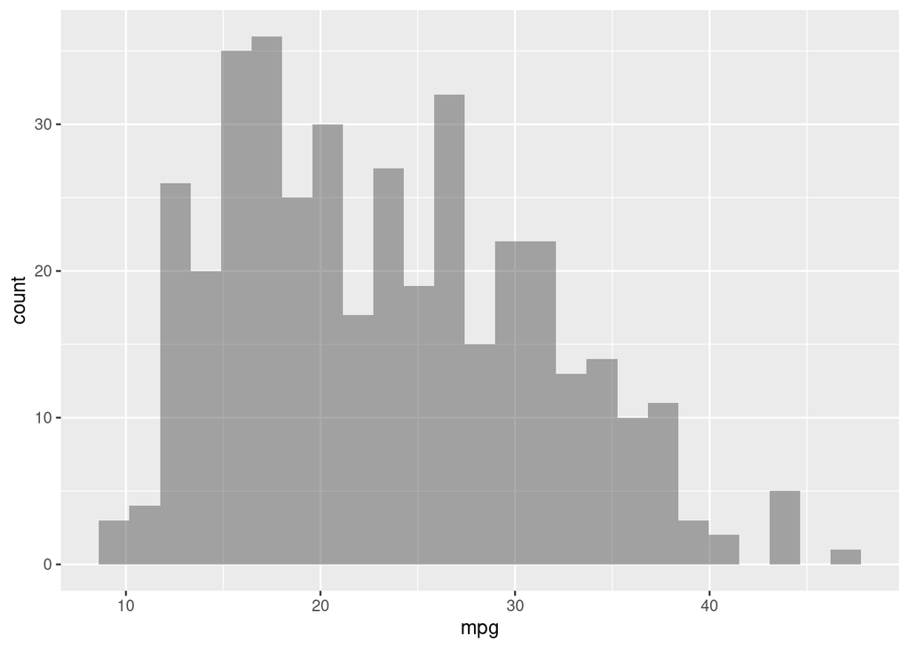

```r
auto_data %>%
  gf_histogram(~mpg)
```

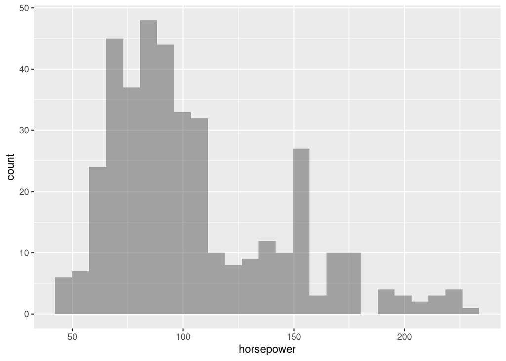

```r
auto_data %>%
  gf_histogram(~horsepower)
```

### Horsepower Histogram

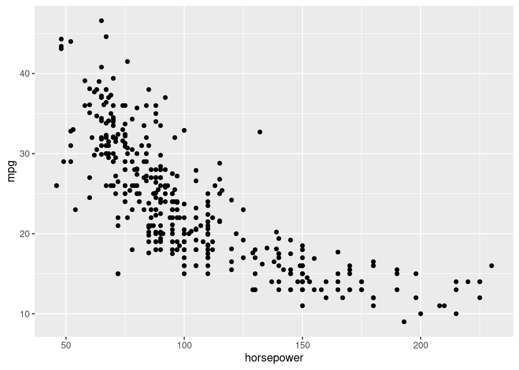

```r
auto_data %>%
  gf_point(mpg~horsepower)
```

## Descripitive statistics

```r
auto_data %>%
  summarise(mean=mean(mpg),sd=sd(mpg))
```

```
##       mean       sd
## 1 23.44592 7.805007
```

```r
auto_data %>%
  summarise(mean=mean(horsepower),sd=sd(horsepower))
```

```
##       mean       sd
## 1 104.4694 38.49116
```

```r
with(auto_data,cor(mpg,horsepower))
```

```
## [1] -0.7784268
```

The average or mean `mpg` is 23.45 based on the results above with a standard deviation of 7.81, showing moderate variability in fuel efficiency. On the other hand, looking at the `horsepower`, the mean is 104.47, with higher variability that is (SD = 38.49). Moreover, from the results, there is a strong negative correlation (-0.78) which indicates that as horsepower increases, fuel efficiency decreases hence highlighting the trade-off between power and efficiency.

```r
favstats(~mpg,data=auto_data)
```

```
##  min Q1 median Q3  max     mean       sd   n missing
##    9 17  22.75 29 46.6 23.44592 7.805007 392       0
```

```r
favstats(~horsepower,data=auto_data)
```

```
##  min Q1 median  Q3 max     mean       sd   n missing
##   46 75   93.5 126 230 104.4694 38.49116 392       0
```

### MPG Summary

The summary shows that fuel efficiency (mpg) ranges from 9 to 46.6, with a median of 22.75. Most cars fall between 17 (Q1) and 29 (Q3), around the average of 23.45. The dataset includes 392 cars, with no missing values.

### Horsepower Summary

The engine power (horsepower) ranges from 46 to 230, with a median of 93.5. Most vehicles lie between 75 (Q1) and 126 (Q3), near the average of 104.47.

## Simple Linear Regression

### a. Perform Simple Linear Regression and Analyze the Output

```r
lm_spec <- linear_reg() %>%
  set_mode("regression") %>%
  set_engine("lm")

lm_spec
```

```
## Linear Regression Model Specification (regression)
##
## Computational engine: lm
```

```r
# Fit the simple linear regression model
slr_mod <- lm(mpg ~ horsepower, data = auto_data)

# Display the regression model summary
tidy(slr_mod)
```

```
## # A tibble: 2 × 5
##   term        estimate std.error statistic   p.value
##   <chr>          <dbl>     <dbl>     <dbl>     <dbl>
## 1 (Intercept)   39.9     0.717        55.7 1.22e-187
## 2 horsepower    -0.158   0.00645     -24.5 7.03e- 81
```

$$\widehat{mpg} = 39.9359 - 0.1578 \times
horsepower$$

#### i. Is there a relationship between the predictor (horsepower) and the response (mpg)?

Yes, the p-value associated with the horsepower coefficient is < 2e-16, which is highly significant, indicating a strong relationship between horsepower and mpg.

#### ii. How strong is the relationship?

The multiple R-squared value is 0.6059, which means that approximately 60.6% of the variability in mpg can be explained by horsepower. This is a moderate relationship.

#### iii. Is the relationship between the predictor and the response positive or negative?

The coefficient for horsepower is negative (-0.157845), indicating a negative relationship between horsepower and mpg. As horsepower increases, mpg tends to decrease.

#### iv. What is the predicted mpg associated with a horsepower of 98?

```r
predict(slr_mod, newdata = data.frame(horsepower = 98))
```

```
##        1
## 24.46708
```

To predict mpg for a horsepower of 98, we can use the regression equation:

For horsepower = 98

mpg=39.935861−0.157845×98=39.935861−15.482=24.46

The predicted mpg is approximately 24.46.

### b. Plot Response vs. Predictor with Regression Line

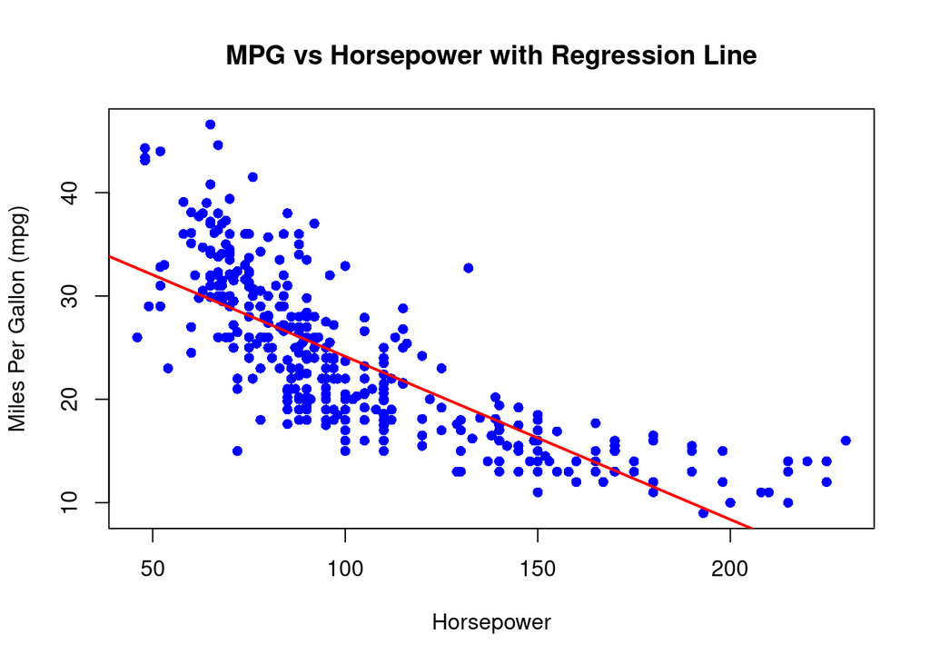

```r
# Plot mpg vs. horsepower and add regression line
plot(auto_data$horsepower, auto_data$mpg,
     xlab = "Horsepower",
     ylab = "Miles Per Gallon (mpg)",
     main = "MPG vs Horsepower with Regression Line",
     pch = 16, col = "blue")

# Add regression line
abline(slr_mod, col = "red", lwd = 2)
```

From the plot above, the negative slope of the regression line confirms an inverse relationship that I can say as horsepower increases, MPG decreases on the other side. This shows that the cars with higher engine power generally have lower fuel efficiency. The data points on the other hand show variability around the line, suggesting some cars deviate from this trend

### c. Diagnostic Plots for Linear Regression Fit

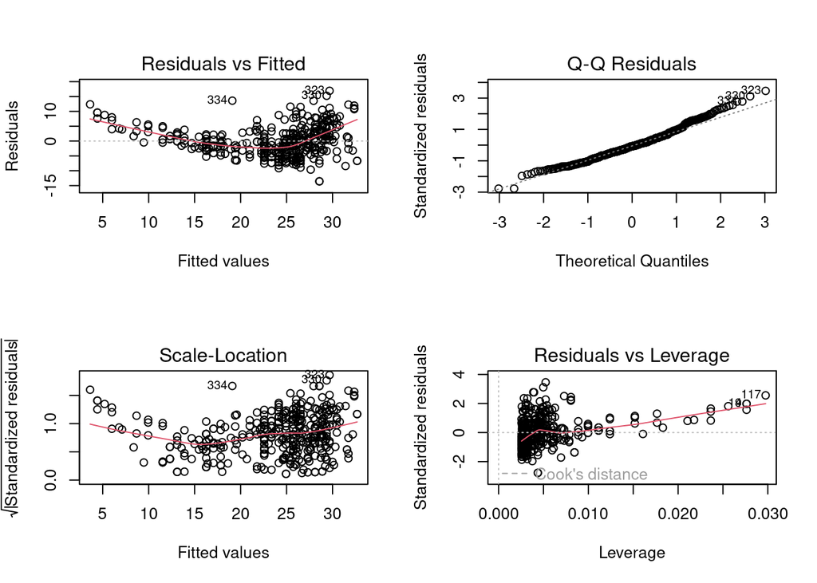

```r
# Generate diagnostic plots
par(mfrow = c(2, 2))
plot(slr_mod)
```

The Residuals vs Fitted plot shows a curved pattern, suggesting the model maybe does not fully capture the non-linear relationship between variables.

On the second plot that is the Q-Q plot indicates residuals are mostly normal, but slight deviations at the tails suggest some non-normality.

The Scale-Location plot reveals increasing residual spread, indicating heteroscedasticity (non-constant error variance), which may affect prediction accuracy.

The Residuals vs Leverage plot highlights influential points that could overly impact the model.

Issues include non-linearity, heteroscedasticity, and influential points, suggesting the model could benefit from adjustments, like transformations or alternative regression methods, for better accuracy.

### d. Generate a ggplot with Raw Data, Prediction Line, and Confidence/Prediction Intervals

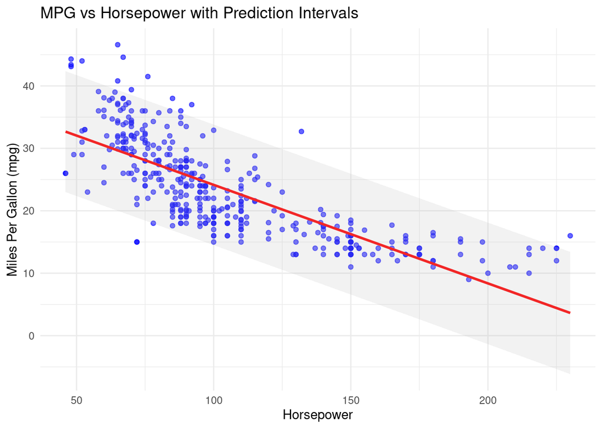

```r
# Add predictions and intervals to the dataset
predictions <- predict(slr_mod, auto_data, interval = "prediction")
auto_data <- auto_data %>%
  mutate(.fitted = predictions[, "fit"],
         .pred_lower = predictions[, "lwr"],
         .pred_upper = predictions[, "upr"])

# Generate ggplot
ggplot(auto_data, aes(x = horsepower, y = mpg)) +
  geom_point(alpha = 0.6, color = "blue") +
  geom_line(aes(y = .fitted), color = "red", size = 1) +
  geom_ribbon(aes(ymin = .pred_lower, ymax = .pred_upper), alpha = 0.2, fill = "grey") +
  labs(
    title = "MPG vs Horsepower with Prediction Intervals",
    x = "Horsepower",
    y = "Miles Per Gallon (mpg)"
  ) +
  theme_minimal()
```

This graphic shows the relationship between horsepower and miles per gallon that is (MPG). The red line above represents the predicted MPG based on horsepower, showing a clear negative trend which can be interpreted as vehicles with higher horsepower tend to have lower MPG. Moreover, the gray shaded area represents the prediction intervals, indicating the range within which most data points are expected to fall. The blue points in the plot highlights the observed data, showing variability but generally aligning with the trend we observed. This reinforces the inverse relationship between horsepower and fuel efficiency.

```r
lm.fit <- lm(mpg~horsepower,data=auto_data)
cbind(predict(lm.fit,interval="confidence"),
      predict(lm.fit,interval="predict")) %>% as_tibble()
```

```
## # A tibble: 392 × 6
##      fit   lwr   upr    V4     V5    V6
##    <dbl> <dbl> <dbl> <dbl>  <dbl> <dbl>
##  1 19.4  18.8  20.0  19.4   9.75   29.1
##  2 13.9  13.0  14.8  13.9   4.20   23.6
##  3 16.3  15.5  17.0  16.3   6.58   25.9
##  4 16.3  15.5  17.0  16.3   6.58   25.9
##  5 17.8  17.2  18.5  17.8   8.17   27.5
##  6  8.68  7.40  9.96  8.68 -1.05   18.4
##  7  5.21  3.67  6.75  5.21 -4.56   15.0
##  8  6.00  4.52  7.48  6.00 -3.76   15.8
##  9  4.42  2.82  6.02  4.42 -5.36   14.2
## 10  9.95  8.76 11.1   9.95  0.227  19.7
## # ℹ 382 more rows
```

```r
tidy(slr_mod) %>% str()
```

```
## tibble [2 × 5] (S3: tbl_df/tbl/data.frame)
##  $ term     : chr [1:2] "(Intercept)" "horsepower"
##  $ estimate : num [1:2] 39.936 -0.158
##  $ std.error: num [1:2] 0.7175 0.00645
##  $ statistic: num [1:2] 55.7 -24.5
##  $ p.value  : num [1:2] 1.22e-187 7.03e-81
```

# Assessing

```r
glance(slr_mod)
```

```
## # A tibble: 1 × 12
##   r.squared adj.r.squared sigma statistic  p.value    df logLik   AIC   BIC
##       <dbl>         <dbl> <dbl>     <dbl>    <dbl> <dbl>  <dbl> <dbl> <dbl>
## 1     0.606         0.605  4.91      600. 7.03e-81     1 -1179. 2363. 2375.
## # ℹ 3 more variables: deviance <dbl>, df.residual <int>, nobs <int>
```

#### Assess with test/train

```r
# Set seed before random split
set.seed(15)

# Put 80% of the data into the training set
auto_split <- initial_split(auto_data, prop = 0.80)

# Assign the two splits to data frames - with descriptive names
auto_train <- training(auto_split)
auto_test <- testing(auto_split)

# Check the splits
head(auto_train)
```

```
##      mpg cylinders displacement horsepower weight acceleration year origin
## 38  18.0         6          232        100   3288         15.5   71      1
## 367 17.6         6          225         85   3465         16.6   81      1
## 164 18.0         6          225         95   3785         19.0   75      1
## 296 35.7         4           98         80   1915         14.4   79      1
## 179 23.0         4          120         88   2957         17.0   75      2
## 263 19.2         8          305        145   3425         13.2   78      1
##                             name  .fitted .pred_lower .pred_upper
## 38                   amc matador 24.15139   14.493888    33.80889
## 367       chrysler lebaron salon 26.51906   16.858575    36.17954
## 164                plymouth fury 24.94061   15.282533    34.59869
## 296  dodge colt hatchback custom 27.30828   17.645972    36.97059
## 179                  peugeot 504 26.04552   16.385936    35.70511
## 263 chevrolet monte carlo landau 17.04837    7.377393    26.71936
```

```r
head(auto_test)
```

```
##    mpg cylinders displacement horsepower weight acceleration year origin
## 3   18         8          318        150   3436         11.0   70      1
## 4   16         8          304        150   3433         12.0   70      1
## 5   17         8          302        140   3449         10.5   70      1
## 16  22         6          198         95   2833         15.5   70      1
## 17  18         6          199         97   2774         15.5   70      1
## 22  24         4          107         90   2430         14.5   70      2
##                  name  .fitted .pred_lower .pred_upper
## 3  plymouth satellite 16.25915    6.584598    25.93370
## 4       amc rebel sst 16.25915    6.584598    25.93370
## 5         ford torino 17.83760    8.169775    27.50542
## 16    plymouth duster 24.94061   15.282533    34.59869
## 17         amc hornet 24.62492   14.967125    34.28272
## 22        audi 100 ls 25.72984   16.070761    35.38891
```

#### Train and fit linear model

```r
# Fit the model using the training data
slr_train <- lm(mpg ~ horsepower, data = auto_train)

# Summarize the model fit
tidy(slr_train)
```

```
## # A tibble: 2 × 5
##   term        estimate std.error statistic   p.value
##   <chr>          <dbl>     <dbl>     <dbl>     <dbl>
## 1 (Intercept)   39.8     0.797        49.9 1.56e-150
## 2 horsepower    -0.157   0.00712     -22.1 1.24e- 65
```

The regression analysis from the training subset above reveals a strong negative relationship between horsepower and MPG. The intercept (39.78) suggests that a vehicle with zero horsepower would theoretically have an MPG of 39.78. The coefficient for horsepower (-0.157) indicates that each additional unit of horsepower decreases MPG by approximately 0.157 units.

```r
# Augment the model to include predictions on the test data
test_aug <- augment(slr_train, new_data = auto_test)

# Check the augmented results
head(test_aug)
```

```
## # A tibble: 6 × 9
##   .rownames   mpg horsepower .fitted .resid    .hat .sigma  .cooksd .std.resid
##   <chr>     <dbl>      <dbl>   <dbl>  <dbl>   <dbl>  <dbl>    <dbl>      <dbl>
## 1 38         18          100    24.1  -6.05 0.00325   4.81 0.00259      -1.26
## 2 367        17.6         85    26.4  -8.81 0.00408   4.79 0.00690      -1.83
## 3 164        18           95    24.8  -6.84 0.00342   4.80 0.00348      -1.42
## 4 296        35.7         80    27.2   8.50 0.00458   4.80 0.00721       1.77
## 5 179        23           88    25.9  -2.94 0.00384   4.82 0.000721     -0.612
## 6 263        19.2        145    17.0   2.23 0.00668   4.82 0.000724      0.464
```

```r
glance(slr_train)
```

```
## # A tibble: 1 × 12
##   r.squared adj.r.squared sigma statistic  p.value    df logLik   AIC   BIC
##       <dbl>         <dbl> <dbl>     <dbl>    <dbl> <dbl>  <dbl> <dbl> <dbl>
## 1     0.610         0.609  4.81      487. 1.24e-65     1  -935. 1876. 1887.
## # ℹ 3 more variables: deviance <dbl>, df.residual <int>, nobs <int>
```

Based on the R-squared which is 0.610, about 61% of the variability in MPG is explained by horsepower, suggesting a moderately strong relationship.

#### Check for Linearity (Residuals vs. Fitted)

```r
train_aug <- augment(slr_train, new_data = auto_train)
head(train_aug)
```

```
## # A tibble: 6 × 9
##   .rownames   mpg horsepower .fitted .resid    .hat .sigma  .cooksd .std.resid
##   <chr>     <dbl>      <dbl>   <dbl>  <dbl>   <dbl>  <dbl>    <dbl>      <dbl>
## 1 38         18          100    24.1  -6.05 0.00325   4.81 0.00259      -1.26
## 2 367        17.6         85    26.4  -8.81 0.00408   4.79 0.00690      -1.83
## 3 164        18           95    24.8  -6.84 0.00342   4.80 0.00348      -1.42
## 4 296        35.7         80    27.2   8.50 0.00458   4.80 0.00721       1.77
## 5 179        23           88    25.9  -2.94 0.00384   4.82 0.000721     -0.612
## 6 263        19.2        145    17.0   2.23 0.00668   4.82 0.000724      0.464
```

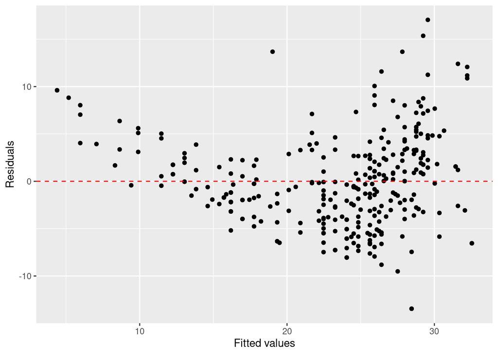

```r
ggplot(data = train_aug, aes(x = .fitted, y = .resid)) +
  geom_point() +
  geom_hline(yintercept = 0, linetype = "dashed", color = "red") +
  xlab("Fitted values") +
  ylab("Residuals")
```

While most residuals cluster around zero, suggesting a reasonable fit, the spread increases for higher fitted values, indicating heteroscedasticity. The pattern above suggests that the model’s variance is not somehow constant, violating a key linear regression assumption. Adjustments, such as transformation or alternative models, may be necessary to improve accuracy and address this issue.

### Plotting residuals

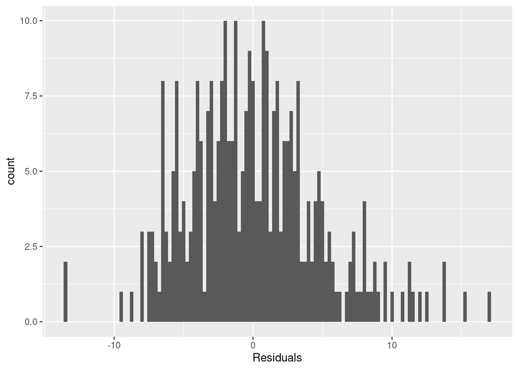

```r
ggplot(data = train_aug, aes(x = .resid)) +
  geom_histogram(binwidth = 0.25) +
  xlab("Residuals")
```

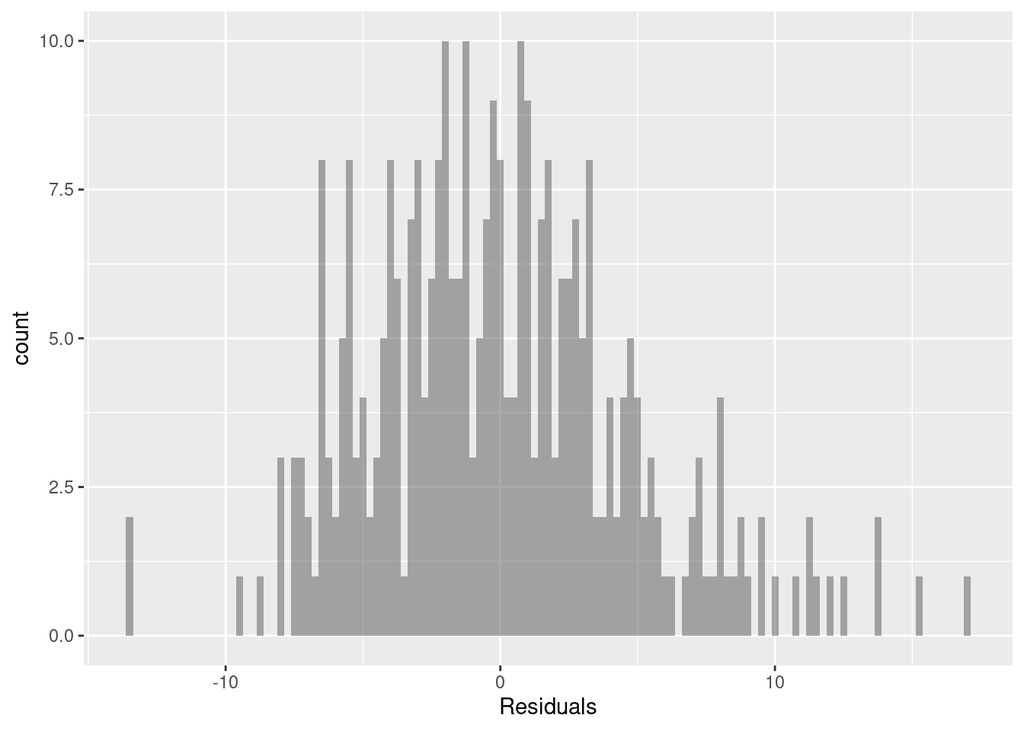

```r
train_aug %>%
  gf_histogram(~.resid,binwidth=.25) %>%
  gf_labs(x="Residuals")
```

The residuals shows slight skewness hence we can say there is normality.

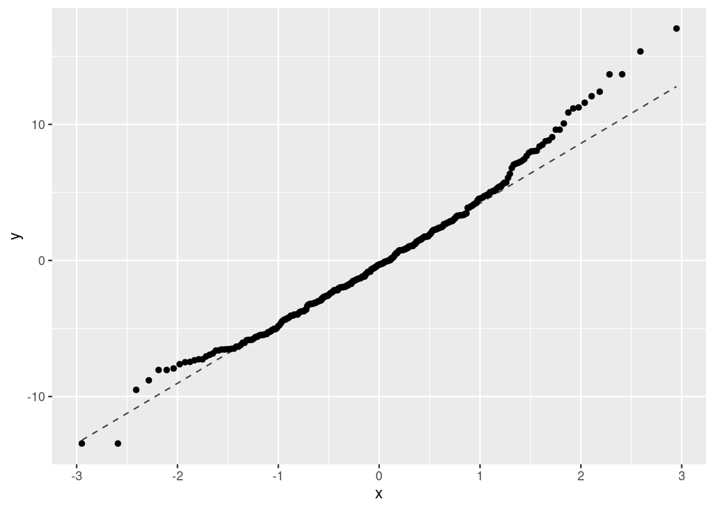

```r
train_aug %>%
  gf_qq(~.resid) %>%
  gf_qqline()
```

I can say the points closely follow the diagonal line in the central region, indicating normality for most residuals, deviations likely occur at both tails as shown in my plot above. The points in the upper and lower extremes diverge from the line as can be observed too, suggesting that the residuals may not be perfectly normally distributed

## Inference: Confidence Intervals

```r
tidy(slr_mod,conf.int=TRUE)
```

```
## # A tibble: 2 × 7
##   term        estimate std.error statistic   p.value conf.low conf.high
##   <chr>          <dbl>     <dbl>     <dbl>     <dbl>    <dbl>     <dbl>
## 1 (Intercept)   39.9     0.717        55.7 1.22e-187   38.5      41.3
## 2 horsepower    -0.158   0.00645     -24.5 7.03e- 81   -0.171    -0.145
```

#### Confidence Intervals for Model Coefficients

```r
# Get confidence intervals for the coefficients
tidy(slr_train, conf.int = TRUE)
```

```
## # A tibble: 2 × 7
##   term        estimate std.error statistic   p.value conf.low conf.high
##   <chr>          <dbl>     <dbl>     <dbl>     <dbl>    <dbl>     <dbl>
## 1 (Intercept)   39.8     0.797        49.9 1.56e-150   38.2      41.3
## 2 horsepower    -0.157   0.00712     -22.1 1.24e- 65   -0.171    -0.143
```

```r
# Predictions with confidence intervals and prediction intervals
cbind(
  predict(slr_train, new_data = auto_data, interval = "confidence"),
  predict(slr_train, new_data = auto_data, interval = "predict")
)
```

```
##           fit       lwr       upr       fit        lwr      upr
## 38  24.051691 23.511609 24.591773 24.051691 14.5663784 33.53700
## 367 26.410776 25.805680 27.015872 26.410776 16.9215394 35.90001
## 164 24.838053 24.284264 25.391842 24.838053 15.3519497 34.32416
## 296 27.197138 26.556352 27.837924 27.197138 17.7055584 36.68872
## 179 25.938959 25.352293 26.525625 25.938959 16.4508798 35.42704
## 263 16.974437 16.200595 17.748278 16.974437  7.4729472 26.47593
## 219 30.657129 29.806855 31.507403 30.657129 21.1491092 40.16515
## 206 27.983499 27.301666 28.665333 27.983499 18.4890605 37.47794
## 368 25.938959 25.352293 26.525625 25.938959 16.4508798 35.42704
## 85  25.938959 25.352293 26.525625 25.938959 16.4508798 35.42704
## 232  9.897182  8.592682 11.201682  9.897182  0.3378311 19.45653
## 195 25.624414 25.048654 26.200175 25.624414 16.1370033 35.11183
## 142 26.725321 26.106654 27.343988 26.725321 17.2352090 36.21543
## 247 31.600763 30.683613 32.517912 31.600763 22.0865295 41.11500
```

[output cut: 299 more lines]

#### Residuals Analysis Function

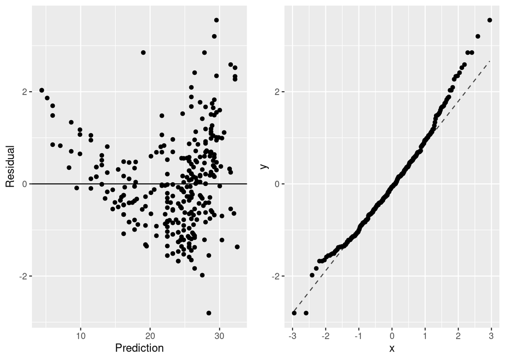

```r
# Define a function to simplify residuals analysis
residualAnalysis <- function(model = NULL) {
  if (!require(gridExtra)) stop('Install the gridExtra package.')
  if (!require(ggformula)) stop('Install the ggformula package.')

  df <- data.frame(Prediction = predict(model),
                   Residual = rstandard(model))

  p1 <- gf_point(Residual ~ Prediction, data = df) %>% gf_hline(yintercept = 0)
  p2 <- gf_qq(~Residual, data = df) %>% gf_qqline()

  grid.arrange(p1, p2, ncol = 2)
}

# Apply the residual analysis function
residualAnalysis(slr_train)
```

## TASK 2

#### Subset the Dataset

```r
# Subset Diamonds Dataset
data("diamonds")
set.seed(1995)
diamond_subset <- diamonds %>%
  sample_n(1000) %>%
  select(price, carat)
```

```r
head(diamond_subset)
```

```
## # A tibble: 6 × 2
##   price carat
##   <int> <dbl>
## 1  2697  0.7
## 2  6093  1.35
## 3  1917  0.81
## 4  1056  0.43
## 5   776  0.3
## 6   866  0.38
```

#### Exploratory Data Analysis (EDA)

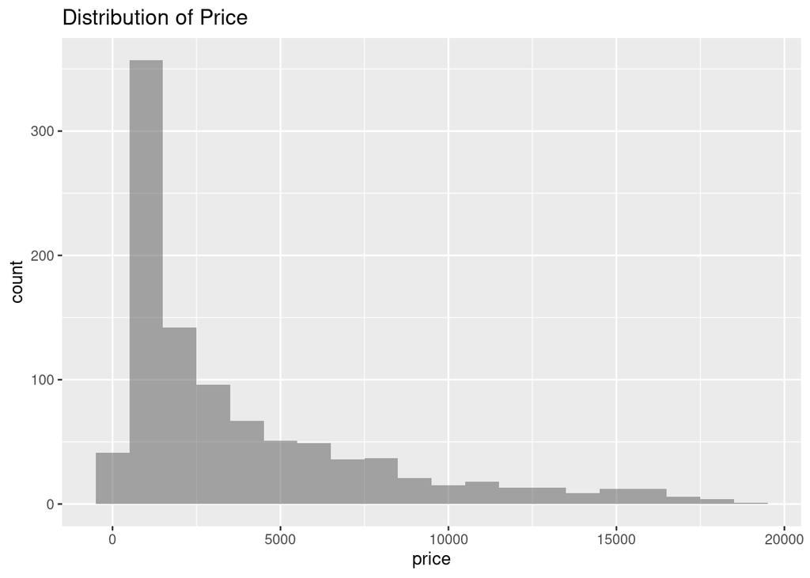

```r
# Histogram of Price
diamond_subset %>%
  gf_histogram(~price, binwidth = 1000) %>%
  gf_labs(title = "Distribution of Price")
```

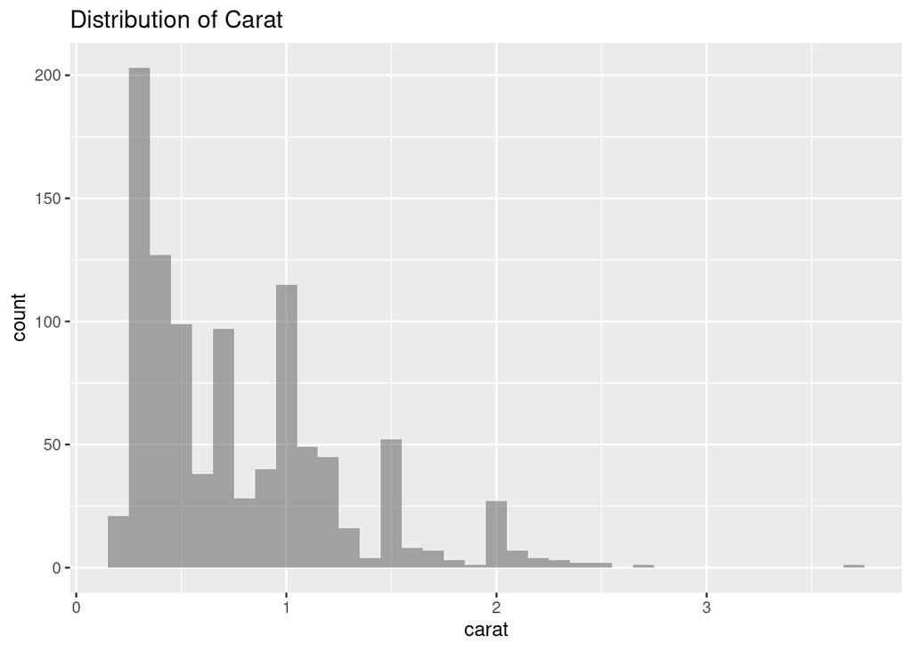

```r
# Histogram of Carat
diamond_subset %>%
  gf_histogram(~carat, binwidth = 0.1) %>%
  gf_labs(title = "Distribution of Carat")
```

#### Scatter Plot for Price vs. Carat

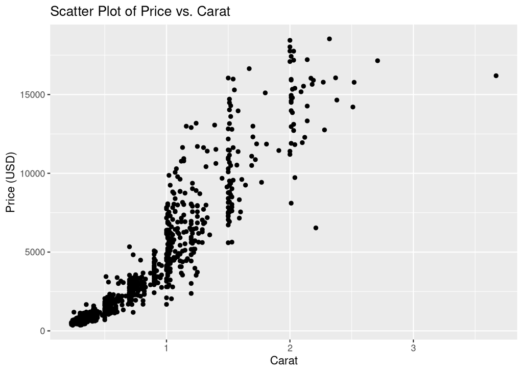

```r
# Scatter Plot: Price vs Carat
diamond_subset %>%
  gf_point(price ~ carat) %>%
  gf_labs(
    title = "Scatter Plot of Price vs. Carat",
    x = "Carat",
    y = "Price (USD)"
  )
```

#### Summary Statistics and Correlation

```r
# Summary statistics for Price
favstats(~price, data = diamond_subset)
```

```
##  min     Q1 median   Q3   max     mean       sd    n missing
##  357 898.75 2191.5 5306 18532 3810.505 3967.046 1000       0
```

```r
# Summary statistics for Carat
favstats(~carat, data = diamond_subset)
```

```
##   min   Q1 median   Q3  max    mean       sd    n missing
##  0.23 0.38    0.7 1.03 3.67 0.78496 0.488944 1000       0
```

```r
# Correlation between Price and Carat
cor(diamond_subset$price, diamond_subset$carat)
```

```
## [1] 0.9302809
```

#### Simple Linear Regression Model

```r
# Specify and Fit the Linear Model
lm_model <- lm(price ~ carat, data = diamond_subset)

# Display Regression Coefficients
summary(lm_model)
```

```
##
## Call:
## lm(formula = price ~ carat, data = diamond_subset)
##
## Residuals:
##     Min      1Q  Median      3Q     Max
## -9393.3  -739.3   -27.4   481.4  6840.5
##
## Coefficients:
##             Estimate Std. Error t value Pr(>|t|)
## (Intercept) -2114.24      87.12  -24.27   <2e-16 ***
## carat        7547.83      94.22   80.11   <2e-16 ***
## ---
## Signif. codes:  0 '***' 0.001 '**' 0.01 '*' 0.05 '.' 0.1 ' ' 1
##
## Residual standard error: 1456 on 998 degrees of freedom
## Multiple R-squared:  0.8654, Adjusted R-squared:  0.8653
## F-statistic:  6418 on 1 and 998 DF,  p-value: < 2.2e-16
```

#### Model Predictions for Specific Values

```r
# Predict Price for Carat = 1.0
predict(lm_model, newdata = data.frame(carat = 1.0))
```

```
##        1
## 5433.591
```

#### Diagnostic Plots for Regression Model

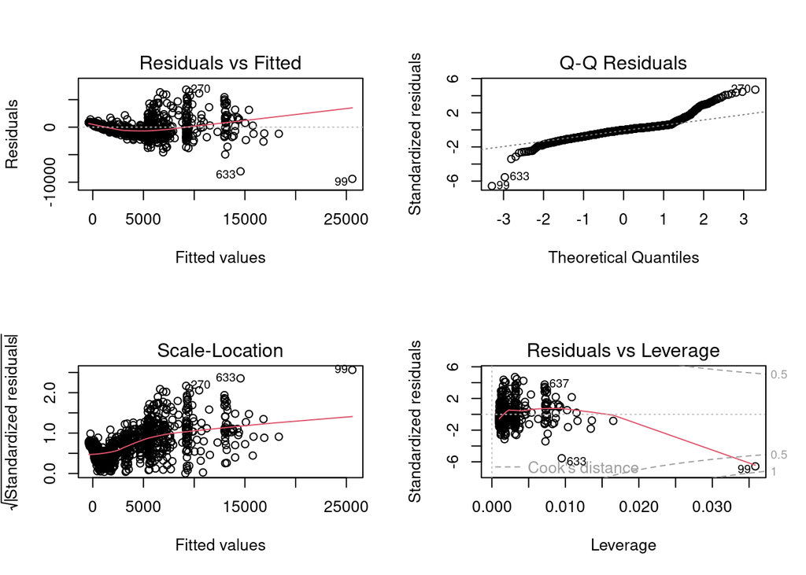

```r
# Diagnostic Plots
par(mfrow = c(2, 2))
plot(lm_model)
```

#### Visualize the Regression Line

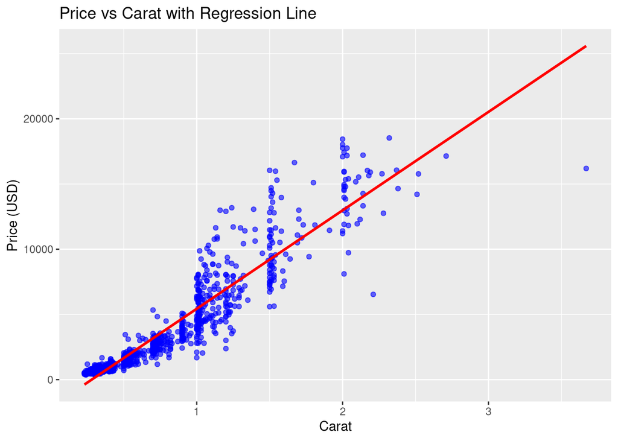

```r
# Scatter Plot with Regression Line
ggplot(diamond_subset, aes(x = carat, y = price)) +
  geom_point(alpha = 0.6, color = "blue") +
  geom_smooth(method = "lm", color = "red", se = FALSE) +
  labs(
    title = "Price vs Carat with Regression Line",
    x = "Carat",
    y = "Price (USD)"
  )
```

#### Confidence and Prediction Intervals

```r
# Add Predictions with Intervals
diamond_subset <- diamond_subset %>%
  mutate(
    .fitted = predict(lm_model),
    .pred_lower = predict(lm_model, interval = "prediction")[, "lwr"],
    .pred_upper = predict(lm_model, interval = "prediction")[, "upr"]
  )
```

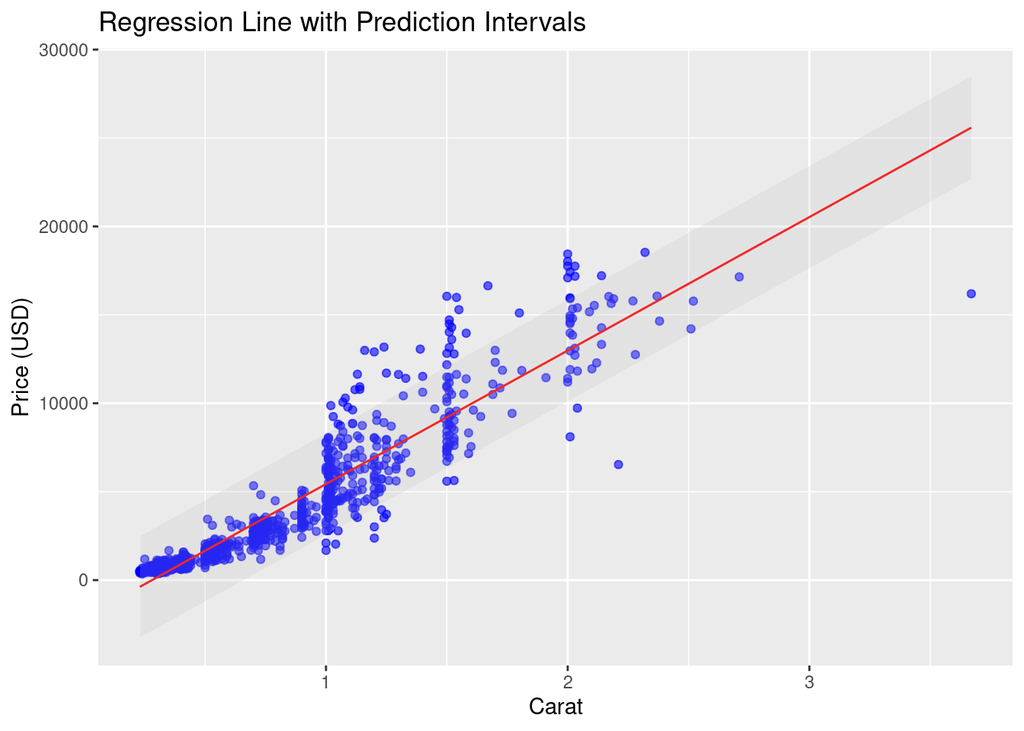

```r
# Plot with Confidence and Prediction Intervals
ggplot(diamond_subset, aes(x = carat, y = price)) +
  geom_point(alpha = 0.6, color = "blue") +
  geom_line(aes(y = .fitted), color = "red") +
  geom_ribbon(aes(ymin = .pred_lower, ymax = .pred_upper), alpha = 0.2, fill = "grey") +
  labs(
    title = "Regression Line with Prediction Intervals",
    x = "Carat",
    y = "Price (USD)"
  )
```

## Assessing

#### Split the Data into Training and Testing Sets

```r
# Split into Train and Test Sets
set.seed(1995)
diamond_split <- initial_split(diamond_subset, prop = 0.8)
diamond_train <- training(diamond_split)
diamond_test <- testing(diamond_split)
```

```r
head(diamond_train)
```

```
## # A tibble: 6 × 5
##   price carat .fitted .pred_lower .pred_upper
##   <int> <dbl>   <dbl>       <dbl>       <dbl>
## 1  6503  1.24   7245.       4385.      10105.
## 2   863  0.34    452.      -2408.       3312.
## 3  1269  0.41    980.      -1879.       3840.
## 4 16036  2.17  14265.      11394.      17135.
## 5  1868  0.57   2188.       -671.       5047.
## 6   790  0.35    528.      -2332.       3387.
```

```r
head(diamond_test)
```

```
## # A tibble: 6 × 5
##   price carat .fitted .pred_lower .pred_upper
##   <int> <dbl>   <dbl>       <dbl>       <dbl>
## 1  4876  1.01   5509.       2650.       8368.
## 2  1911  0.58   2264.       -595.       5122.
## 3  7859  1.53   9434.       6572.      12296.
## 4  1668  0.52   1811.      -1048.       4670.
## 5  1675  0.55   2037.       -822.       4896.
## 6  2167  0.56   2113.       -746.       4972.
```

#### Train Linear Regression Model on Training Data

```r
# Train the Model on Training Data
train_model <- lm(price ~ carat, data = diamond_train)

# Summary of the Model
summary(train_model)
```

```
##
## Call:
## lm(formula = price ~ carat, data = diamond_train)
##
## Residuals:
##     Min      1Q  Median      3Q     Max
## -9451.8  -755.3   -19.4   480.7  6816.3
##
## Coefficients:
##             Estimate Std. Error t value Pr(>|t|)
## (Intercept)  -2113.8      100.7  -20.99   <2e-16 ***
## carat         7563.7      107.5   70.35   <2e-16 ***
## ---
## Signif. codes:  0 '***' 0.001 '**' 0.01 '*' 0.05 '.' 0.1 ' ' 1
##
## Residual standard error: 1512 on 798 degrees of freedom
## Multiple R-squared:  0.8611, Adjusted R-squared:  0.861
## F-statistic:  4949 on 1 and 798 DF,  p-value: < 2.2e-16
```

#### Evaluate Model on Test Data

```r
# Predict on Test Data
test_predictions <- predict(train_model, newdata = diamond_test)

# Combine Predictions with Actual Data
test_results <- diamond_test %>%
  mutate(
    predicted_price = test_predictions,
    residuals = price - test_predictions
  )

# View Results
head(test_results)
```

```
## # A tibble: 6 × 7
##   price carat .fitted .pred_lower .pred_upper predicted_price residuals
##   <int> <dbl>   <dbl>       <dbl>       <dbl>           <dbl>     <dbl>
## 1  4876  1.01   5509.       2650.       8368.           5525.    -649.
## 2  1911  0.58   2264.       -595.       5122.           2273.    -362.
## 3  7859  1.53   9434.       6572.      12296.           9459.   -1600.
## 4  1668  0.52   1811.      -1048.       4670.           1819.    -151.
## 5  1675  0.55   2037.       -822.       4896.           2046.    -371.
## 6  2167  0.56   2113.       -746.       4972.           2122.      45.2
```

#### Residual Analysis on Test Data

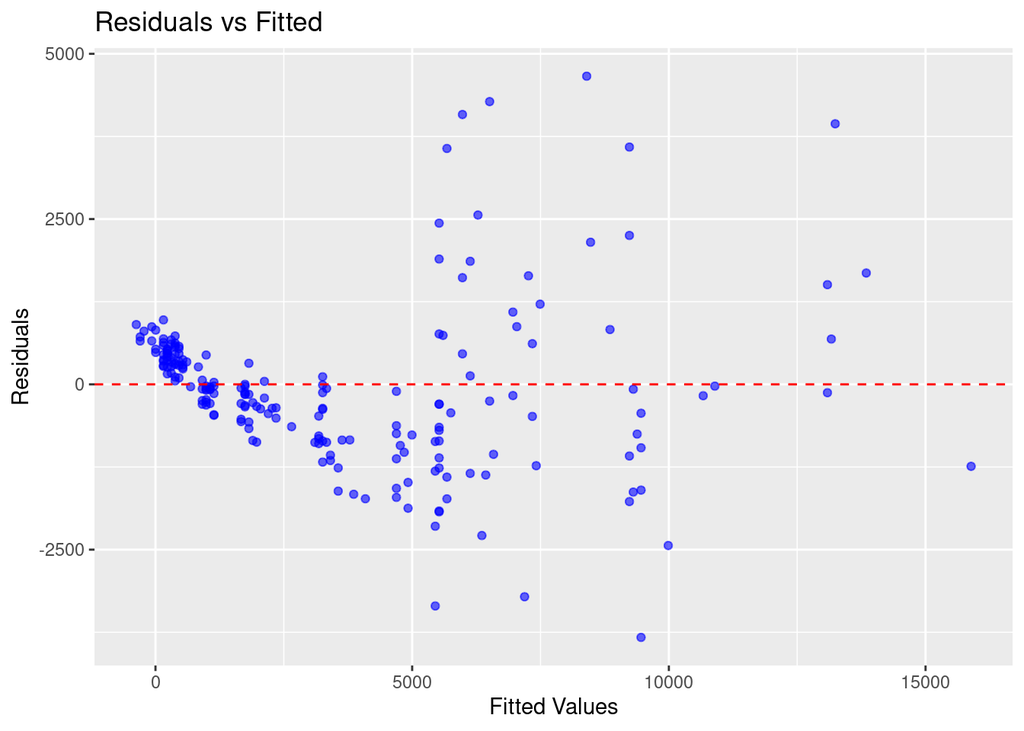

```r
# Plot Residuals vs Fitted
ggplot(test_results, aes(x = predicted_price, y = residuals)) +
  geom_point(alpha = 0.6, color = "blue") +
  geom_hline(yintercept = 0, linetype = "dashed", color = "red") +
  labs(
    title = "Residuals vs Fitted",
    x = "Fitted Values",
    y = "Residuals"
  )
```

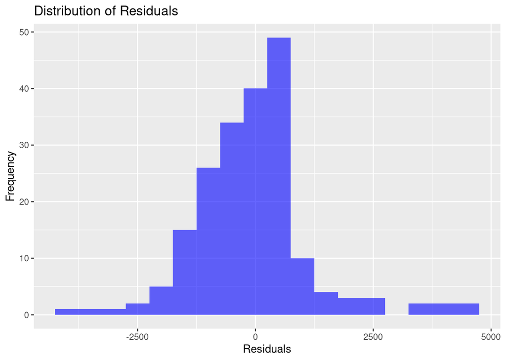

```r
# Histogram of Residuals
ggplot(test_results, aes(x = residuals)) +
  geom_histogram(binwidth = 500, fill = "blue", alpha = 0.6) +
  labs(
    title = "Distribution of Residuals",
    x = "Residuals",
    y = "Frequency"
  )
```

#### Confidence Intervals for Coefficients

```r
# Confidence Intervals
confint(train_model)
```

```
##                 2.5 %    97.5 %
## (Intercept) -2311.444 -1916.156
## carat        7352.602  7774.714
```

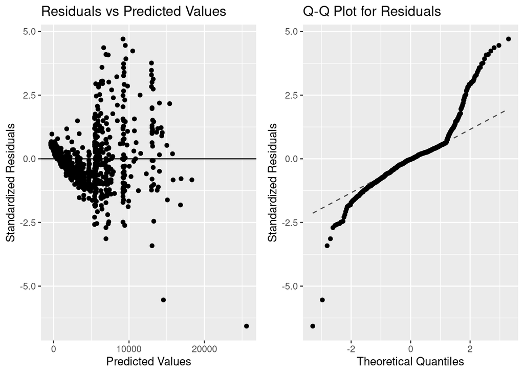

```r
# Define a function to simplify residuals analysis
residualAnalysis <- function(model = NULL) {
  if (!require(gridExtra)) stop('Install the gridExtra package.')
  if (!require(ggformula)) stop('Install the ggformula package.')

  # Create a dataframe with predictions and standardized residuals
  df <- data.frame(
    Prediction = predict(model),
    Residual = rstandard(model)
  )

  # Plot residuals vs predictions
  p1 <- gf_point(Residual ~ Prediction, data = df) %>%
    gf_hline(yintercept = 0) %>%
    gf_labs(
      title = "Residuals vs Predicted Values",
      x = "Predicted Values",
      y = "Standardized Residuals"
    )

  # Q-Q Plot for residuals
  p2 <- gf_qq(~Residual, data = df) %>%
    gf_qqline() %>%
    gf_labs(
      title = "Q-Q Plot for Residuals",
      x = "Theoretical Quantiles",
      y = "Standardized Residuals"
    )

  # Combine the plots in a grid
  grid.arrange(p1, p2, ncol = 2)
}

# Apply the residual analysis function on the trained model
residualAnalysis(lm_model)
```